# Part I - (ProsperLoan Dataset)

## by (Abbey Christian Banafo)

## Introduction

> *This data is from [Prosper.com](https://www.prosper.com/), a money lendeng platform where people make money from those who borrow based on the interest rates.This data set contains 113,937 loans with 81 variables on each loan, including loan amount, borrower rate (or interest rate), current loan status, borrower income, and many others. See this [data dictionary](https://docs.google.com/spreadsheets/d/1gDyi_L4UvIrLTEC6Wri5nbaMmkGmLQBk-Yx3z0XDEtI/edit#gid=0) to understand the dataset's variables. In our case, we would want to know more about factors that may be responsible for borrowers to receive loan from this platform as well as the APR(Annual Percentage Rate) associated with it. Factors including the monthly income, the loan amounts, prosperscores which is a custom risk score built using historical Prosper data as well as other factors were most considerd during the exploration phase.*

## Preliminary Wrangling

```python
# import all packages and set plots to be embedded inline
import numpy as np
import pandas as pd
import matplotlib.pyplot as plt
import seaborn as sb

%matplotlib inline
```

## *Gathering data phase*

> *The only dataset needed for this project was from the udacity platform, a Prosperloan dataset csv file.*

```python
loan = pd.read_csv('prosperLoandata.csv')
```

### *Assessment of DATASET*

```python
pd.set_option("display.max_columns", len(loan.columns)) #display the maximum number of columns
loan.head()
```

|  | ListingKey | ListingNumber | ListingCreationDate | CreditGrade | Term | LoanStatus | ClosedDate | BorrowerAPR | BorrowerRate | LenderYield | EstimatedEffectiveYield | EstimatedLoss | EstimatedReturn | ProsperRating (numeric) | ProsperRating (Alpha) | ProsperScore | ListingCategory (numeric) | BorrowerState | Occupation | EmploymentStatus | EmploymentStatusDuration | IsBorrowerHomeowner | CurrentlyInGroup | GroupKey | DateCreditPulled | CreditScoreRangeLower | CreditScoreRangeUpper | FirstRecordedCreditLine | CurrentCreditLines | … |
| --- | --- | --- | --- | --- | --- | --- | --- | --- | --- | --- | --- | --- | --- | --- | --- | --- | --- | --- | --- | --- | --- | --- | --- | --- | --- | --- | --- | --- | --- | --- |
| 0 | 1021339766868145413AB3B | 193129 | 2007-08-26 19:09:29.263000000 | C | 36 | Completed | 2009-08-14 00:00:00 | 0.16516 | 0.1580 | 0.1380 | NaN | NaN | NaN | NaN | NaN | NaN | 0 | CO | Other | Self-employed | 2.0 | True | True | NaN | 2007-08-26 18:41:46.780000000 | 640.0 | 659.0 | 2001-10-11 00:00:00 | 5.0 | … |
| 1 | 10273602499503308B223C1 | 1209647 | 2014-02-27 08:28:07.900000000 | NaN | 36 | Current | NaN | 0.12016 | 0.0920 | 0.0820 | 0.07960 | 0.0249 | 0.05470 | 6.0 | A | 7.0 | 2 | CO | Professional | Employed | 44.0 | False | False | NaN | 2014-02-27 08:28:14 | 680.0 | 699.0 | 1996-03-18 00:00:00 | 14.0 | … |
| 2 | 0EE9337825851032864889A | 81716 | 2007-01-05 15:00:47.090000000 | HR | 36 | Completed | 2009-12-17 00:00:00 | 0.28269 | 0.2750 | 0.2400 | NaN | NaN | NaN | NaN | NaN | NaN | 0 | GA | Other | Not available | NaN | False | True | 783C3371218786870A73D20 | 2007-01-02 14:09:10.060000000 | 480.0 | 499.0 | 2002-07-27 00:00:00 | NaN | … |
| 3 | 0EF5356002482715299901A | 658116 | 2012-10-22 11:02:35.010000000 | NaN | 36 | Current | NaN | 0.12528 | 0.0974 | 0.0874 | 0.08490 | 0.0249 | 0.06000 | 6.0 | A | 9.0 | 16 | GA | Skilled Labor | Employed | 113.0 | True | False | NaN | 2012-10-22 11:02:32 | 800.0 | 819.0 | 1983-02-28 00:00:00 | 5.0 | … |
| 4 | 0F023589499656230C5E3E2 | 909464 | 2013-09-14 18:38:39.097000000 | NaN | 36 | Current | NaN | 0.24614 | 0.2085 | 0.1985 | 0.18316 | 0.0925 | 0.09066 | 3.0 | D | 4.0 | 2 | MN | Executive | Employed | 44.0 | True | False | NaN | 2013-09-14 18:38:44 | 680.0 | 699.0 | 2004-02-20 00:00:00 | 19.0 | … |

```python
# checking dataset shape
loan.shape
```

```
(113937, 81)
```

```python
# brief description about the data set
loan.describe()
```

|  | ListingNumber | Term | BorrowerAPR | BorrowerRate | LenderYield | EstimatedEffectiveYield | EstimatedLoss | EstimatedReturn | ProsperRating (numeric) | ProsperScore | ListingCategory (numeric) | EmploymentStatusDuration | CreditScoreRangeLower | CreditScoreRangeUpper | CurrentCreditLines | OpenCreditLines | TotalCreditLinespast7years | OpenRevolvingAccounts | OpenRevolvingMonthlyPayment | InquiriesLast6Months | TotalInquiries | CurrentDelinquencies | AmountDelinquent | DelinquenciesLast7Years | PublicRecordsLast10Years | PublicRecordsLast12Months | RevolvingCreditBalance | BankcardUtilization | AvailableBankcardCredit | … |
| --- | --- | --- | --- | --- | --- | --- | --- | --- | --- | --- | --- | --- | --- | --- | --- | --- | --- | --- | --- | --- | --- | --- | --- | --- | --- | --- | --- | --- | --- | --- |
| count | 1.139370e+05 | 113937.000000 | 113912.000000 | 113937.000000 | 113937.000000 | 84853.000000 | 84853.000000 | 84853.000000 | 84853.000000 | 84853.000000 | 113937.000000 | 106312.000000 | 113346.000000 | 113346.000000 | 106333.000000 | 106333.000000 | 113240.000000 | 113937.00000 | 113937.000000 | 113240.000000 | 112778.000000 | 113240.000000 | 106315.000000 | 112947.000000 | 113240.000000 | 106333.000000 | 1.063330e+05 | 106333.000000 | 106393.000000 | … |
| mean | 6.278857e+05 | 40.830248 | 0.218828 | 0.192764 | 0.182701 | 0.168661 | 0.080306 | 0.096068 | 4.072243 | 5.950067 | 2.774209 | 96.071582 | 685.567731 | 704.567731 | 10.317192 | 9.260164 | 26.754539 | 6.96979 | 398.292161 | 1.435085 | 5.584405 | 0.592052 | 984.507059 | 4.154984 | 0.312646 | 0.015094 | 1.759871e+04 | 0.561309 | 11210.225447 | … |
| std | 3.280762e+05 | 10.436212 | 0.080364 | 0.074818 | 0.074516 | 0.068467 | 0.046764 | 0.030403 | 1.673227 | 2.376501 | 3.996797 | 94.480605 | 66.458275 | 66.458275 | 5.457866 | 5.022644 | 13.637871 | 4.63097 | 447.159711 | 2.437507 | 6.429946 | 1.978707 | 7158.270157 | 10.160216 | 0.727868 | 0.154092 | 3.293640e+04 | 0.317918 | 19818.361309 | … |
| min | 4.000000e+00 | 12.000000 | 0.006530 | 0.000000 | -0.010000 | -0.182700 | 0.004900 | -0.182700 | 1.000000 | 1.000000 | 0.000000 | 0.000000 | 0.000000 | 19.000000 | 0.000000 | 0.000000 | 2.000000 | 0.00000 | 0.000000 | 0.000000 | 0.000000 | 0.000000 | 0.000000 | 0.000000 | 0.000000 | 0.000000 | 0.000000e+00 | 0.000000 | 0.000000 | … |
| 25% | 4.009190e+05 | 36.000000 | 0.156290 | 0.134000 | 0.124200 | 0.115670 | 0.042400 | 0.074080 | 3.000000 | 4.000000 | 1.000000 | 26.000000 | 660.000000 | 679.000000 | 7.000000 | 6.000000 | 17.000000 | 4.00000 | 114.000000 | 0.000000 | 2.000000 | 0.000000 | 0.000000 | 0.000000 | 0.000000 | 0.000000 | 3.121000e+03 | 0.310000 | 880.000000 | … |
| 50% | 6.005540e+05 | 36.000000 | 0.209760 | 0.184000 | 0.173000 | 0.161500 | 0.072400 | 0.091700 | 4.000000 | 6.000000 | 1.000000 | 67.000000 | 680.000000 | 699.000000 | 10.000000 | 9.000000 | 25.000000 | 6.00000 | 271.000000 | 1.000000 | 4.000000 | 0.000000 | 0.000000 | 0.000000 | 0.000000 | 0.000000 | 8.549000e+03 | 0.600000 | 4100.000000 | … |
| 75% | 8.926340e+05 | 36.000000 | 0.283810 | 0.250000 | 0.240000 | 0.224300 | 0.112000 | 0.116600 | 5.000000 | 8.000000 | 3.000000 | 137.000000 | 720.000000 | 739.000000 | 13.000000 | 12.000000 | 35.000000 | 9.00000 | 525.000000 | 2.000000 | 7.000000 | 0.000000 | 0.000000 | 3.000000 | 0.000000 | 0.000000 | 1.952100e+04 | 0.840000 | 13180.000000 | … |
| max | 1.255725e+06 | 60.000000 | 0.512290 | 0.497500 | 0.492500 | 0.319900 | 0.366000 | 0.283700 | 7.000000 | 11.000000 | 20.000000 | 755.000000 | 880.000000 | 899.000000 | 59.000000 | 54.000000 | 136.000000 | 51.00000 | 14985.000000 | 105.000000 | 379.000000 | 83.000000 | 463881.000000 | 99.000000 | 38.000000 | 20.000000 | 1.435667e+06 | 5.950000 | 646285.000000 | … |

```python
# checking brief info in data
loan.info()
```

```
<class 'pandas.core.frame.DataFrame'>
RangeIndex: 113937 entries, 0 to 113936
Data columns (total 81 columns):
 #   Column                               Non-Null Count   Dtype
---  ------                               --------------   -----
 0   ListingKey                           113937 non-null  object
 1   ListingNumber                        113937 non-null  int64
 2   ListingCreationDate                  113937 non-null  object
 3   CreditGrade                          28953 non-null   object
 4   Term                                 113937 non-null  int64
 5   LoanStatus                           113937 non-null  object
 6   ClosedDate                           55089 non-null   object
 7   BorrowerAPR                          113912 non-null  float64
 8   BorrowerRate                         113937 non-null  float64
 9   LenderYield                          113937 non-null  float64
```

[output cut: 73 more lines]

```python
loan.LoanStatus.value_counts().sum()
```

```
113937
```

### *Quality Issues*

> - **(1)** *Nan values in BorrowerAPR, EstimatedReturn, ProsperRatingAlpha, CreditGrades and EstimatedEffectiveyield columns*
> - **(2)** *Numbers as listing categories*
> - **(7)** *ProsperScore values greater than 10*
> - **(4)** *ListingCategories(numeric), ProsperRating (numeric) naming*
> - **(6)** *Some Columns may not be needed for analysis*
> - **(3)** *Nan values in'ProsperRating', 'ProsperScore', 'EstimatedLoss', 'EmploymentStatusDuration', 'CreditScoreRangeLower', CurrentCreditLines', 'TotalCreditLinespast7years'*
> - **(8)** *Incorrect datatypes for some variables LoanStatus, ProsperScore, ProsperRating (numeric) and others*

### *Tiddiness Issues*

> - **(5)** *Some columns may not be need for or investigation*
> - **(6)** *Other nan values in rows*

## *Cleaning*

### *Quality Issues*

*Some Columns within the dataset seems to have large number of missing values hence, we would want to fill in those with the means and medians of their respective roles or use the calculations that leeds to such figures*

### Issue 1

*Nan values in BorrowerAPR, EstimatedReturn, ProsperRatingAlpha, CreditGrades and EstimatedEffectiveyield columns.*

*BorrowerAPR*

> *The **BorrowerAPR** values may be of interest and about 25 loans are missing this value. Because APR is equal to the borrower rate + fees, let's calculate the difference between the two and find the mean, and add that value to the borrower rate of our data missing an APR.*

*Define*

> - *Find difference between BorrowerAPR and BorrowerRate*
> - *Find the mean of the above*
> - *Fill null BorrowerAPR values with the mean Calculated*

*Coding and Testing*

```python
# Calculating the difference and mean for the APR
borrower_fees = loan["BorrowerAPR"] - loan["BorrowerRate"]
borrower_fees.mean()
```

```
0.026041364737690028
```

```python
# filling in null APR values with mean difference
loan["BorrowerAPR"].fillna(loan["BorrowerRate"] + borrower_fees.mean(), inplace=True)
loan["BorrowerAPR"].isnull().sum()
```

```
0
```

*EstimatedEffectiveYield*

> *From the variable definitions, the **effective yield** is equal to the borrower interest rate (i) minus the servicing fee rate, (ii) minus estimated uncollected interest on charge-offs, (iii) plus estimated collected late fees which could be thought of as being equivalent to the borrower rate minus some expected loss from interest charge-offs and fees.*

*Define*

> - *Compute difference in BorrowerRate and the EstimatedEffectiveYield*
> - *Find the mean of the difference*
> - *Fill in null values with the mean*

*Coding and Testing*

```python
# filling null values with mean difference
estimated_loss_from_fees = loan["BorrowerRate"] - loan["EstimatedEffectiveYield"]
estimated_loss_from_fees.mean()
```

```
0.027360274474679962
```

```python
#  filling null values with mean difference
loan["EstimatedEffectiveYield"].fillna(loan["BorrowerRate"] - estimated_loss_from_fees.mean(), inplace=True)
loan["EstimatedEffectiveYield"].isnull().sum()
```

```
0
```

*EstimatedReturn*

*Again from the variables definitions, the **EstimatedReturn** is the difference between the **EstimatedEffectiveYield** and the **EstimatedLoss** Rate.*

*Define*

> - *Find the difference between the estimated yield and the estimated loss*
> - *Find the mean of the above*
> - *Fill in the null values with the mean above*

*Coding and Testing*

```python
# filling null values with median difference
loan["EstimatedReturn"].fillna((loan["EstimatedEffectiveYield"] - loan["EstimatedLoss"]).mean(), inplace=True)
loan["EstimatedReturn"].isnull().sum()
```

```
0
```

*Credit Grade*

> *The **credit Grade** and **ProsperRating (Alpha)** seems to be a categorical data type with lots of NAN values, hence would like to assign the nan values with the **NONE** instead*

*Define*

> - *Fill in nan values with **'NONE'** instead*

*Coding and Testing*

```python
# Filling in null values with NONE
loan['CreditGrade'].fillna('NONE', inplace = True)
loan['CreditGrade'].isnull().sum()
```

```
0
```

*ProsperRating (Alpha)*

> - *It appears most of these null values have values 0f 4.07 slightly greater that those graded as C*
> - *We would thus like to fill in the null values with C+ to indicate they are slightly above the C level*

*Define*

> - *Fill in the null values with C+*

*Coding and Testing*

```python
#Chose C+ for uniformity
loan['ProsperRating (Alpha)'].fillna('C+', inplace = True)
loan['ProsperRating (Alpha)'].isnull().sum()
```

```
0
```

### *Issue 2*

> *Numbers as listing categories*

*The **ListingCategory (numeric)** column seems to give a false impression of being an **ordinal** Categorical Variable but is not hence would love to assign the actual names associated with the numeric variables assigned to it and thus rename it as **ListingCategory** as well*. *The column as well appears to be of type **int** hence would need to be coverted in a categorical data type.*

*Define*

> - *Replace all number with their appropriate Categories fromm the [data dictionary](https://docs.google.com/spreadsheets/d/1gDyi_L4UvIrLTEC6Wri5nbaMmkGmLQBk-Yx3z0XDEtI/edit#gid=0)*
> - *Covert the datatype to Categoric*
> - *Rename the column to **ListingCategory**.*

*Coding and Testing*

```python
# Assigning actual listing names to the ListingCategory Variable
loan.replace(to_replace={"ListingCategory (numeric)": {0: "Unknown", 1: "Debt", 2: "Home Improvement", 3: "Business", 4: "Personal",
                                                                5: "Student", 6: "Auto", 7: "Other", 8: "Baby & Adoption", 9: "Boat",
                                                                10: "Cosmetic", 11: "Engagement", 12: "Green Loans", 13: "Household",
                                                                14: "LargePurchases", 15: "Medical", 16: "Motorcycle", 17: "RV",
                                                                18: "Taxes", 19: "Vacation", 20: "Wedding"}}, inplace=True)

# changing ListingCategory (numeric) into categorical data type
loan['ListingCategory (numeric)'] = pd.Categorical(loan['ListingCategory (numeric)'])

loan.rename(columns={'ListingCategory (numeric)': 'ListingCategory'}, inplace=True)
```

```python
# Confirming changes made to data type
loan.ListingCategory.dtype
```

```
CategoricalDtype(categories=['Auto', 'Baby & Adoption', 'Boat', 'Business', 'Cosmetic',
                  'Debt', 'Engagement', 'Green Loans', 'Home Improvement',
                  'Household', 'LargePurchases', 'Medical', 'Motorcycle',
                  'Other', 'Personal', 'RV', 'Student', 'Taxes', 'Unknown',
                  'Vacation', 'Wedding'],
, ordered=False)
```

### *Issue 3*

*Nan values in **'ProsperRating'**, **'ProsperScore'**, **'EstimatedLoss'**, **'EmploymentStatusDuration'**, **'CreditScoreRangeLower'**, **'CurrentCreditLines'**, **'TotalCreditLinespast7years'**.*

*Define*

> - *Rename the ProsperRating (numeric) column to enable dot notation*
> - *Create a list to assign all the column names into it*
> - *Write a loop to fill in all the null values for the columns*

*For values in the **variables** variable below, the mean was computed using the mean of the pandas series and filling in the null values with those figures.*

*Coding and Testing*

```python
loan.rename(columns={'ProsperRating (numeric)': 'ProsperRating'}, inplace=True) #rename ProperRating to enable dot notation in python

variables = ['ProsperRating', 'ProsperScore', 'EstimatedLoss', 'EmploymentStatusDuration',
             'CreditScoreRangeLower', 'CurrentCreditLines', 'TotalCreditLinespast7years'
            ]
# looping through the variables and filling in with the mean values for each column
for i in range(len(variables)):
    loan[variables[i]].fillna(loan[variables[i]].mean(), inplace=True)

loan[['ProsperRating', 'ProsperScore', 'EstimatedLoss', 'EmploymentStatusDuration',
             'CreditScoreRangeLower', 'CurrentCreditLines', 'TotalCreditLinespast7years']]
```

|  | ProsperRating | ProsperScore | EstimatedLoss | EmploymentStatusDuration | CreditScoreRangeLower | CurrentCreditLines | TotalCreditLinespast7years |
| --- | --- | --- | --- | --- | --- | --- | --- |
| 0 | 4.072243 | 5.950067 | 0.080306 | 2.000000 | 640.0 | 5.000000 | 12.0 |
| 1 | 6.000000 | 7.000000 | 0.024900 | 44.000000 | 680.0 | 14.000000 | 29.0 |
| 2 | 4.072243 | 5.950067 | 0.080306 | 96.071582 | 480.0 | 10.317192 | 3.0 |
| 3 | 6.000000 | 9.000000 | 0.024900 | 113.000000 | 800.0 | 5.000000 | 29.0 |
| 4 | 3.000000 | 4.000000 | 0.092500 | 44.000000 | 680.0 | 19.000000 | 49.0 |
| ... | ... | ... | ... | ... | ... | ... | ... |
| 113932 | 4.000000 | 5.000000 | 0.069900 | 246.000000 | 700.0 | 9.000000 | 41.0 |
| 113933 | 6.000000 | 8.000000 | 0.020000 | 21.000000 | 700.0 | 14.000000 | 39.0 |
| 113934 | 3.000000 | 3.000000 | 0.102500 | 84.000000 | 700.0 | 12.000000 | 25.0 |
| 113935 | 4.000000 | 5.000000 | 0.085000 | 94.000000 | 680.0 | 11.000000 | 22.0 |
| 113936 | 6.000000 | 7.000000 | 0.029900 | 244.000000 | 680.0 | 10.000000 | 44.0 |

113937 rows × 7 columns

### *Issue 4*

*ListingCategories(numeric), ProsperRating (numeric) naming*

> - *Solved in Issue 2 and 3 above*

### *Issue 7*

*ProsperScore values greater than 10*

> *From the variables definition, prosper score values a not to go beyound 10*

*Define*

> *Drop all columns with prosperScore values greater than 10*

*Coding and Testing*

```python
loan.ProsperScore.value_counts()
```

```
5.950067     29084
4.000000     12595
6.000000     12278
8.000000     12053
7.000000     10597
5.000000      9813
3.000000      7642
9.000000      6911
2.000000      5766
10.000000     4750
11.000000     1456
1.000000       992
Name: ProsperScore, dtype: int64
```

```python
# droping properscore values greater than 10
loan = loan[~(loan.ProsperScore > 10)] # ~ means exclude

# Verifying changes made
sum(loan['ProsperScore']> 10)
```

```
0
```

### *Issue 8*

*Incorrect datatypes for some variables **LoanStatus**, **ProsperScore**,**Occupation**, **ProsperRating (numeric)** and others*

> - *In as much as the **values for the ProsperScore column is numeric**, the column by itself **seems to be categoric** as borrowers are given these numbers based on certain criteria. The numbers assigned also seems to **have certain orders** hence, exhibiting an **ordinal type** variable. As a result we would want to assign an order to this values as well*
> - *The loan status column would be a bit challenging as to considering it as being an ordinal of norminal type data. The Loan Status Column could be thought of as being Ordinal since persons who have completed may be considered better those current or overdue even though there could be futher questions as to when the loan was taken. Irrespective of all these analysis, we would want to consider this column as being a norminal type as current loanStatus persons is a bit confusing to FinalPamentInProgress cos one could be in both. The sum of the value counts of the different status was equivalent to the sum of th individual loanStatus groups but in reality one cannot tell the exact reason as to why they may be in that state **hence we would consider this a norminal type data(without order)**.*
> - *The **Occupation** column seems categorical, hence would love to convert this column to a category datatype. The category is more likely to be of the norminal type of hence there would be no need for ordering.*

```python
print(loan.LoanStatus.value_counts())
sum(loan.LoanStatus.value_counts())
```

```
Current                   55157
Completed                 38043
Chargedoff                11992
Defaulted                  5017
Past Due (1-15 days)        805
Past Due (31-60 days)       363
Past Due (61-90 days)       312
Past Due (91-120 days)      304
Past Due (16-30 days)       265
FinalPaymentInProgress      202
Past Due (>120 days)         16
Cancelled                     5
Name: LoanStatus, dtype: int64
```

```
112481
```

*Define*

> - *Round ProsperScore values to 2dp*
> - *Set up order for the ordinal type variables (ProsperScore and ProsperRating (numeric))*
> - *Change datatype to Categorical*

*Coding and Testing*

```python
loan['ProsperScore'] = loan['ProsperScore'].round(2) # rounding all ProsperScore values to 2dp

ProsperScore_Order = [1.0, 2.0, 3.0, 4.0, 5.0, 5.95, 6.0, 7.0, 8.0, 9.0, 10.0]

AlphaRating_Order = ['AA', 'A', 'B', 'C', 'C+', 'D', 'E', 'HR'] # the C+ was assigned earlier in filling of null values

# changing ProsperRating Alpha into categorical data type
loan['ProsperRating (Alpha)'] = pd.Categorical(loan['ProsperRating (Alpha)'], categories=AlphaRating_Order, ordered=True)

# changing ProperScore datatype to categorical data type
loan['ProsperScore'] = pd.Categorical(loan['ProsperScore'], categories=ProsperScore_Order, ordered=True)

# changing LoanStatus datatype to categorical data type
loan['LoanStatus'] = pd.Categorical(loan['LoanStatus'])

# Converting Occupation column datatype to Category
loan['Occupation'] = pd.Categorical(loan['Occupation'])
```

### *Issue 5*

*Some columns may not be need for or investigation*

> *Some columns may not be of interest to us as for the purpose of what we intend to achive from the data hence it would be appropriate to drop such columns to improve execution time*

*Define*

> - *Create a list that contains the name of the columns with no interest in*
> - *Drop the Columns in the list above from our dataset.*

*Coding and Testing*

```python
# checkingout column length
len(loan.columns)
```

```
81
```

```python
# Removing columns that may not be useful for insights wanted
dropped_columns = ['ScorexChangeAtTimeOfListing', 'TotalProsperLoans', 'TotalProsperPaymentsBilled',
                   'OnTimeProsperPayments', 'ProsperPaymentsLessThanOneMonthLate',
                   'ProsperPaymentsOneMonthPlusLate', 'ProsperPrincipalBorrowed',
                   'ProsperPrincipalOutstanding', 'ListingKey', 'ListingNumber', 'LoanNumber',
                   'ListingCreationDate', 'ClosedDate', 'DateCreditPulled',
                   'LoanOriginationDate', 'LoanOriginationQuarter', 'MemberKey',
                   'LoanCurrentDaysDelinquent', 'LoanFirstDefaultedCycleNumber',
                   'LoanMonthsSinceOrigination', 'LP_CustomerPayments', 'GroupKey',
                   'LP_CustomerPrincipalPayments', 'LP_InterestandFees', 'LP_ServiceFees',
                   'LP_CollectionFees', 'LP_GrossPrincipalLoss', 'LP_NetPrincipalLoss', 'LP_NonPrincipalRecoverypayments']
```

```python
loan = loan.drop(dropped_columns, axis = 1)
```

```python
# Verifying columns dropped
len(loan.columns)
```

```
52
```

```python
# quick info from data so far
loan.info()
```

```
<class 'pandas.core.frame.DataFrame'>
Int64Index: 112481 entries, 0 to 113936
Data columns (total 52 columns):
 #   Column                              Non-Null Count   Dtype
---  ------                              --------------   -----
 0   CreditGrade                         112481 non-null  object
 1   Term                                112481 non-null  int64
 2   LoanStatus                          112481 non-null  category
 3   BorrowerAPR                         112481 non-null  float64
 4   BorrowerRate                        112481 non-null  float64
 5   LenderYield                         112481 non-null  float64
 6   EstimatedEffectiveYield             112481 non-null  float64
 7   EstimatedLoss                       112481 non-null  float64
 8   EstimatedReturn                     112481 non-null  float64
 9   ProsperRating                       112481 non-null  float64
```

[output cut: 44 more lines]

### *Issue 6*

*Other nan values in rows*

> *At this point we would want drop any null value withing our dataset*

*Define*

> Drop all rows containing any null value

*Coding and Testing*

```python
# Dropping rows with null values in dataset
loan.dropna(inplace=True)
loan.info()
```

```
<class 'pandas.core.frame.DataFrame'>
Int64Index: 93462 entries, 0 to 113936
Data columns (total 52 columns):
 #   Column                              Non-Null Count  Dtype
---  ------                              --------------  -----
 0   CreditGrade                         93462 non-null  object
 1   Term                                93462 non-null  int64
 2   LoanStatus                          93462 non-null  category
 3   BorrowerAPR                         93462 non-null  float64
 4   BorrowerRate                        93462 non-null  float64
 5   LenderYield                         93462 non-null  float64
 6   EstimatedEffectiveYield             93462 non-null  float64
 7   EstimatedLoss                       93462 non-null  float64
 8   EstimatedReturn                     93462 non-null  float64
 9   ProsperRating                       93462 non-null  float64
```

[output cut: 44 more lines]

```python
loan.shape
```

```
(93462, 52)
```

```python
# save as a csv file
loan.to_csv('loan_clean.csv', index=False)

#Make a copy of the cleaned dataset
loan_df = loan.copy()
```

### What is the structure of your dataset?

> There were 113,937 total loans given out for the original dataset. Of this, there are 81 unique variables depicting the condition and criteria for each loan. After cleaning the dataset however, ther happens to be 93,462 total loans with 52 columns that would be needed for our analysis. There seems to be more quantitative variables as compared to categorical types within the data.

### What is/are the main feature(s) of interest in your dataset?

> We would want to **investigate the factors that may be responsible for lending out loan **to members of the **Prosper Loan **Organization as well as the possible **APR**(Annual Percentage Rates) rates associated with them.************

### What features in the dataset do you think will help support your investigation into your feature(s) of interest?

> Factors such as the employment status, monthly income, BorrowerApr, loan lending records of borowers, Occupation, ProsperScore, Loan Amount, Recomendations could help determine the features interested in this dataset.

## Univariate Exploration

> *This phase of the project involves visualization of a single variable*

### *What are the distributions of the amount of loan given to Borrowers from the Prosper DataBase*

```python
# Quick description of Amount of loan Borrowed
loan_df.LoanOriginalAmount.describe()
```

```
count    93462.000000
mean      8652.936894
std       6302.099036
min       1000.000000
25%       4000.000000
50%       7000.000000
75%      12500.000000
max      35000.000000
Name: LoanOriginalAmount, dtype: float64
```

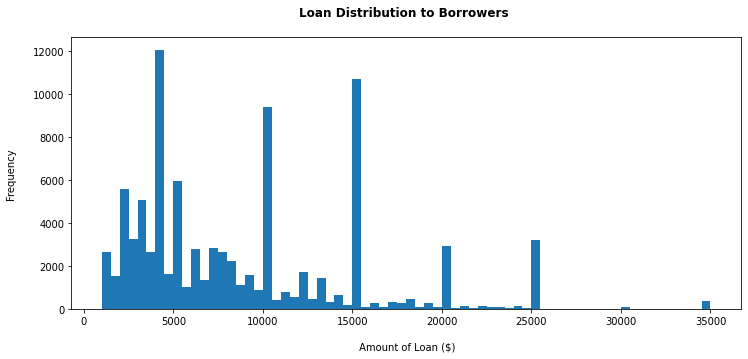

```python
bins = np.arange(loan_df.LoanOriginalAmount.min(), loan_df.LoanOriginalAmount.max()+500, 500)
plt.figure(figsize=(12, 5));
plt.hist(data=loan_df, x='LoanOriginalAmount', bins=bins);
plt.xlabel('\n Amount of Loan ($)');
plt.ylabel('Frequency \n')
plt.title('Loan Distribution to Borrowers \n', fontweight='bold');
```

*From the distribution of the amounts above, It appears most borrowers received not more than **\$15,000**. Majority of the borrowers received amount ranging fom a region around **\$1,000** to about **\$10,000**. The most predominant of these however, are between **\$4,000** to **\$4,500**, **\$10,000** to **\$10,500** as well as from **\$15,000** to **\$15,500** amount values. There also appears to be some rise in the number of people associated with higher amounts of **\$20,000**, and **\$25,000** at the far end of the distribution. There seems to be a wide gab int terms of numbers between the amounts being given up to **\$15,000** and those beyond that. The distribution seems to be fairly skewed to the right on the linear scale*

## *Logarithmic Scaling of amount*

*Since the distribution seems to be clustered within the **\$15,000 range**, a logarithm scaling could help view the distribution of the number of persons at the high income ends better*

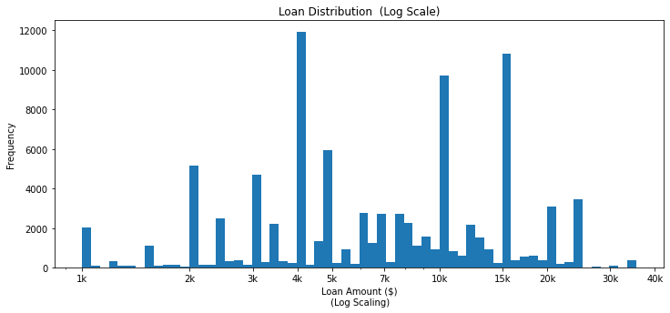

```python
log_binsize = 0.025
bins = 10 ** np.arange(np.log10(loan_df['LoanOriginalAmount'].min()), np.log10(loan_df['LoanOriginalAmount'].max())+log_binsize, log_binsize)

plt.figure(figsize=(12, 5));
plt.hist(data = loan_df, x = 'LoanOriginalAmount', bins = bins)
plt.xscale('log')
plt.xticks([1e3, 2e3, 3e3, 4e3, 5e3, 7e3, 1e4, 1.5e4, 2e4, 3e4, 4e4], ['1k', '2k', '3k', '4k', '5k', '7k', '10k', '15k', '20k', '30k', '40k'])
plt.xlabel('Loan Amount ($)\n (Log Scaling)')
plt.ylabel('Frequency')
plt.title('Loan Distribution  (Log Scale)');
```

*The distribution of the amount lent seems fairly symmetrical on a logarithmic scale with the most dominant peek once again at the **\$4,000** mark. Amounts between **\$4,000** and **\$15,000** seems to have a chunck of the data with high picks at **\$2k, \$3k, \$20k and around \$25k** as well.*

## *What Occupation is given loan the most?*

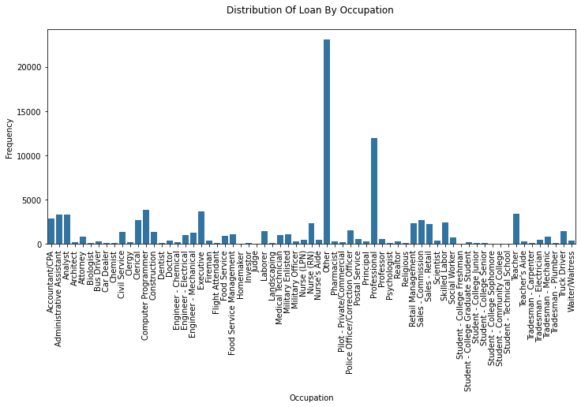

```python
plt.figure(figsize =(12, 5))
color = sb.color_palette()[0]
sb.countplot(data=loan_df, x ='Occupation', color = color)
plt.xticks(rotation=90)
plt.ylabel('Frequency')
plt.title('Distribution Of Loan By Occupation \n');
```

*The high counts associated with **professional** and **Other** columns seems tricky in this sense.The **Professional** and **Other** Occupations seems ambigious upon second thought as occupations such **computer Programming, Professors, Engineers and similiar** ones could as well be considered professional. Also, the **Others** occupation as well seems redundant since we could as well consider other occupations within as being others. We would hence drop these Occupations.*

### *Excluding Other and Professional Occupations from dataset*

```python
#  Excluding Other and Professional from Occupation Column
exclude_other_professional = loan_df[~((loan_df.Occupation == 'Other') | (loan_df.Occupation == 'Professional'))] # ~ means exclude
# Testing code
exclude_other_professional.head()['Occupation']
```

```
3     Skilled Labor
4         Executive
6    Sales - Retail
7           Laborer
8      Food Service
Name: Occupation, dtype: category
Categories (67, object): ['Accountant/CPA', 'Administrative Assistant', 'Analyst', 'Architect', ..., 'Tradesman - Mechanic', 'Tradesman - Plumber', 'Truck Driver', 'Waiter/Waitress']
```

*Lets have a look at the graph for the Occassions distribution with the exclude_other_professional dataset this time around*

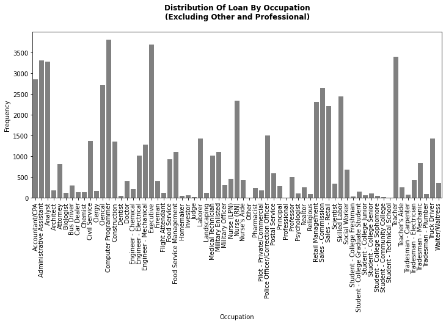

```python
# Visualizing the Occupational Distribution excluding Other and Professional
plt.figure(figsize =(12, 5))
sb.countplot(data=exclude_other_professional, x ='Occupation', color = 'grey')
plt.xticks(rotation=90)
plt.ylabel('Frequency')
plt.title('Distribution Of Loan By Occupation\n(Excluding Other and Professional)\n', fontweight='bold');
```

*.**Computer Programming, Executives as well as Teachers** seems to show more dominance for this particular case. But then why is this the case? Could this be as a result of salary, their numbers, where they come from or what? This leaves as with more questions of which we would want to delve more into later on in the process.*

## *Logarithmic ploting for occupational distribution*

*Once again, Occupations with high number of counts makes it almost imposible to visualize the values for those with lower counts hence we would want to scale their count on logarithm term to have a clearer view for these values*

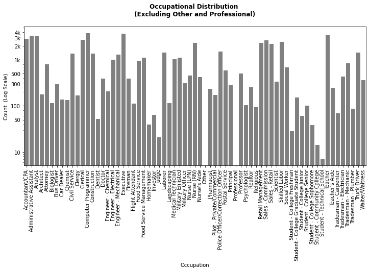

```python
# Logarithmic plotting for Occupational Distribution
plt.figure(figsize=(12, 5))
sb.countplot(data = exclude_other_professional, x = 'Occupation', color = 'grey')
plt.yscale('log')
plt.xticks(rotation = 90)
plt.yticks([10, 50, 100, 300, 500, 1e3, 2e3, 3e3, 4e3], [10, 50, 100, 300, 500, '1k', '2k', '3k', '4k'])
# plt.yticks([1e3, 2e3, 3e3, 4e3, 5e3, 7e3, 1e4, 1.5e4, 2e4, 3e4, 4e4], ['1k', '2k', '3k', '4k', '5k', '7k', '10k', '15k', '20k', '30k', '40k'])
plt.ylabel('Count  (Log Scale)')
plt.title('Occupational Distribution \n(Excluding Other and Professional)\n', fontweight='bold');
```

*The log distribution of the Occupations reveals much at the lower end of this spectrum with few occupations having counts below the 50th count and a significant amount falling within the 300 and 3,000 counts. Again **Computer Programing**, **Executive** and **Teaching** proved dominant but then with **Administrative Assistant**, **Analyst**, **Sales** and a few other Occupations revealing themselves much.*

## What are the most common Monthly Income of Borrowers of Prosper?

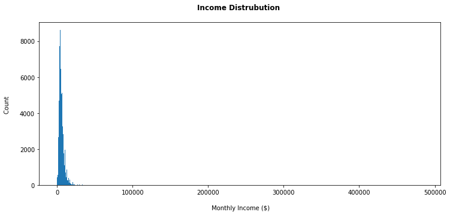

```python
bins = np.arange(loan_df.StatedMonthlyIncome.min(), loan_df.StatedMonthlyIncome.max()+100, 500)
plt.figure(figsize=(12, 5));
plt.hist(data=loan_df, x='StatedMonthlyIncome', bins=bins)
plt.xlabel('\n Monthly Income (\$)')
plt.ylabel('Count \n')
# plt.xlim(0, 20000)
plt.title('Income Distrubution \n', fontweight='bold');
```

*The distribution seems to be stretched out and positively skewed with most salaries within the first few dollar range of somewhere around the **\$30,000** dollar mark.*

*Lets have a description of this column to see what may be happening*

```python
loan_df['StatedMonthlyIncome'].describe()
```

```
count     93462.000000
mean       5717.866173
std        4910.409157
min           0.000000
25%        3333.333333
50%        4833.333333
75%        6958.333333
max      483333.333333
Name: StatedMonthlyIncome, dtype: float64
```

*The difference between the maximum and minimum value for this column seems so wide. With a mean of around **\$5,000** and a maximum value of about **\$483,333** indeed implies most of the values is expected to be clustered around the very beginings of the graph considering the quartile distributions as well.*

*Lets try and findout the number of Monthly incomes greater than a place where the counts begin to deminish significantly, somewhere between **\$20,000** to **\$100,000** salary mark*

## *Finding threshold point where number of people involved drops drastically*

```python
# finding out number of counts for salaries around significant low count regions
amount_threshold = [10000, 20000, 30000, 50000, 100000]
for i in amount_threshold:
    print(len(loan_df.loc[loan_df.StatedMonthlyIncome > i]['StatedMonthlyIncome'].index), loan_df.shape[0])
```

```
8047 93462
895 93462
224 93462
50 93462
7 93462
```

*It appears that, of the **93,462** unique loans given out, less than a **1,000** of the quantity given was above **\$20,000**. This figure even dropped significantly again when compared to salaries above **\$30,000**, **\$50,000** and **\$100,000** to be **224**, **50** and **7** loans lent out respectively. These values to me, seems sightly insignificant compared to the total number of loans given out. The data above at the end looks plausible enough as going to the top would imply the number of people to indeed drop by numbers*

*Lets limit the monthly amounts to **\$40,000** as the number of people with monthly income above this point seems much highly insignificant at this point*

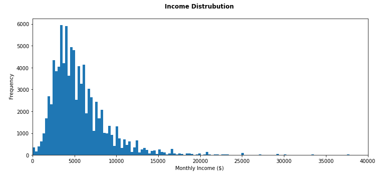

```python
bins = np.arange(loan_df.StatedMonthlyIncome.min(), loan_df.StatedMonthlyIncome.max()+300, 300)
plt.figure(figsize=(12, 5));
plt.hist(data=loan_df, x='StatedMonthlyIncome', bins=bins)
plt.xlabel('Monthly Income ($) \n')
plt.ylabel('\n Frequency')
plt.xlim(0, 40000)
plt.title('Income Distrubution \n', fontweight='bold');
```

*The distribution yet still looks highly skewed to the right with lower count salaries almost invisible to see, hence, we would want to scale this up on a log level to visualize this much better*

## *Log plot for Monthly income distribution*

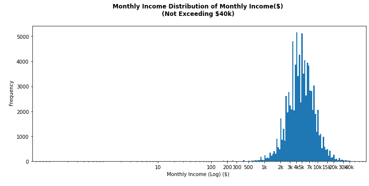

```python
log_binsize = 0.025
bins = 10 ** np.arange(np.log10(loan_df['StatedMonthlyIncome'].min()+0.083333), np.log10(40000)+log_binsize, log_binsize)
plt.figure(figsize=(12, 5));
plt.hist(data = loan_df, x = 'StatedMonthlyIncome', bins = bins)
plt.xscale('log')
plt.xticks([10, 100, 200, 300, 500, 1e3, 2e3, 3e3, 4e3, 5e3, 7e3, 1e4, 1.5e4, 2e4, 3e4, 4e4], [10, 100, 200, 300, 500, '1k', '2k', '3k', '4k', '5k', '7k', '10k', '15k', '20k', '30k', '40k'])
plt.xlabel('Monthly Income (Log) ($) \n')
plt.ylabel('\n Frequency')
plt.title('Monthly Income Distribution of Monthly Income(\$) \n(Not Exceeding \$40k) \n', fontweight='bold');
```

*The bulk of the graph seems to originate from the **\$100** mark to somewhere around the **\$40,000** value on the log scale. Lets try and shift our focus on where the bulk of the data is concentrated*

## *Focussing on where most borrowers fall within*

> *A place around **\$1k** to **\$40k** monthly income.*

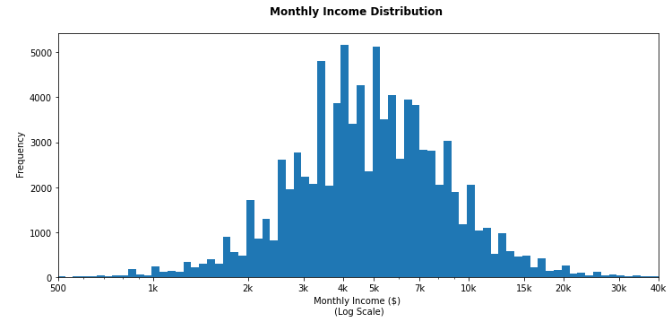

```python
log_binsize = 0.025
bins = 10 ** np.arange(np.log10(loan_df['StatedMonthlyIncome'].min()+0.083333), np.log10(40000)+log_binsize, log_binsize)

plt.figure(figsize=(12, 5));
plt.hist(data = loan_df, x = 'StatedMonthlyIncome', bins = bins)
plt.xscale('log')
plt.xticks([500, 1e3, 2e3, 3e3, 4e3, 5e3, 7e3, 1e4, 1.5e4, 2e4, 3e4, 4e4], [500, '1k', '2k', '3k', '4k', '5k', '7k', '10k', '15k', '20k', '30k', '40k'])
# plt.xticks([100, 200, 300, 400, 500, 600, 1e3], [100, 200, 300, 400, 500, 600, '1k'])
plt.xlim(500, 40000)
plt.xlabel('Monthly Income (\$) \n (Log Scale)')
plt.ylabel('\n Frequency')
plt.title('Monthly Income Distribution \n', fontweight='bold');
```

*The graph seems to be fairly symetrical within this range with a majority of monthly income ranging from the **\$1,000** to **\$20,000** salaries. It also seems to have bimodal peaks around **\$4k** and **\$5.5k**.*

*Lets dive deeper into what is happpening at the lower end of the spectrum*

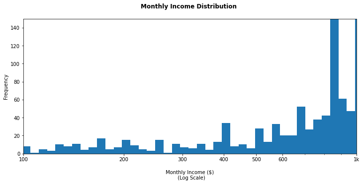

```python
log_binsize = 0.025
bins = 10 ** np.arange(np.log10(loan_df['StatedMonthlyIncome'].min()+0.083333), np.log10(40000)+log_binsize, log_binsize)

plt.figure(figsize=(12, 5));
plt.hist(data = loan_df, x = 'StatedMonthlyIncome', bins = bins)
plt.xscale('log')
# plt.xticks([10, 100, 200, 300, 500, 1e3, 2e3, 3e3, 4e3, 5e3, 7e3, 1e4, 1.5e4, 2e4, 3e4, 4e4], [10, 100, 200, 300, 500, '1k', '2k', '3k', '4k', '5k', '7k', '10k', '15k', '20k', '30k', '40k'])
plt.xticks([100, 200, 300, 400, 500, 600, 1e3], [100, 200, 300, 400, 500, 600, '1k'])
plt.xlim(100, 1000)
plt.ylim(0, 150)
plt.xlabel('\n Monthly Income ($) \n  (Log Scale)')
plt.ylabel('Frequency')
plt.title('Monthly Income Distribution \n', fontweight='bold');
```

*The monthly salary of these lenders seems to increase gradually to the **\$1k** mark and then somehow seems to rise a bit sharply to somewhere around the **\$2.7k** later on and even much more steeper to the **\$4k** mark*

*There as well seems to be insights that needs to be seeked with regards to monthly incomes being equal to **\$0.00**.*

```python
print(loan_df.loc[loan_df.StatedMonthlyIncome < 1]['StatedMonthlyIncome'].value_counts())
print(loan_df.loc[loan_df.StatedMonthlyIncome < 5]['StatedMonthlyIncome'].value_counts())
```

```
0.083333    129
0.000000      1
0.250000      1
Name: StatedMonthlyIncome, dtype: int64
0.083333    129
2.916667      5
3.000000      4
2.500000      3
2.416667      3
1.833333      2
4.333333      2
3.333333      2
3.750000      2
3.583333      1
1.916667      1
3.166667      1
0.250000      1
0.000000      1
3.416667      1
2.666667      1
3.083333      1
3.833333      1
1.416667      1
2.333333      1
4.500000      1
2.083333      1
Name: StatedMonthlyIncome, dtype: int64
```

*Upon second thought, we would want to maintain this as lenders may achieve money from other sources which may not neccessary be on monthly bases*

## *How are the listing Categories Distributed?*

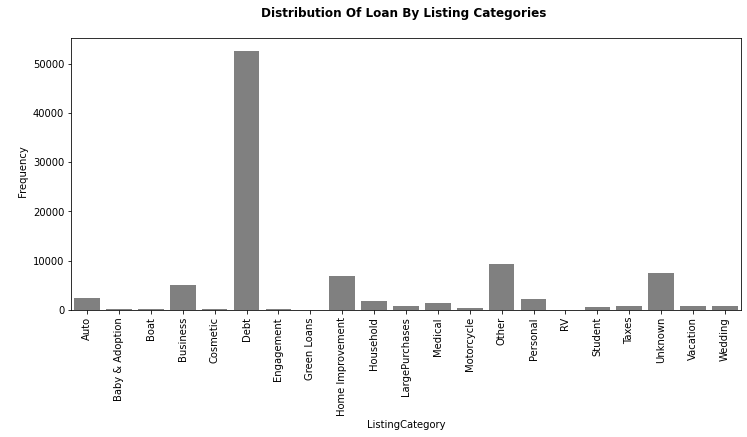

```python
plt.figure(figsize =(12, 5))
# color = sb.color_palette()[0]
sb.countplot(data=loan_df, x ='ListingCategory', color='grey')
plt.xticks(rotation=90)
plt.ylabel('\n Frequency')
plt.title('Distribution Of Loan By Listing Categories \n', fontweight='bold');
```

*It appears majority of borrowers from Prosper seem to own depts of which they intend to settle. It could also imply one could use that as a means to go in for loans but would have to be delved more into later on*

*Again, Categories with low counts seems almost invisible from on a linear scale hence would want visualize this on a logarithmic session*

## *Logarithmic distribution of Listing Categories*

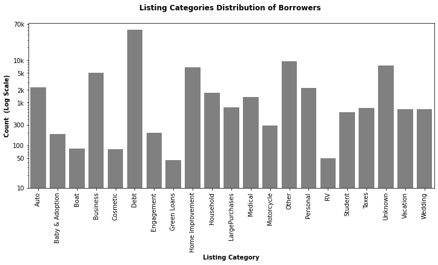

```python
# Logarithmic plotting for Occupational Distribution
plt.figure(figsize=(12, 5))
sb.countplot(data = loan_df, x = 'ListingCategory', color='grey')
plt.yscale('log')
plt.xticks(rotation = 90)
plt.yticks([10, 50, 100, 300, 1e3, 2e3, 5e3, 1e4,7e4], [10, 50, 100, 300, '1k', '2k', '5k', '10k', '70k'])
plt.xlabel('Listing Category', fontweight='bold')
plt.ylabel('Count  (Log Scale)', fontweight='bold')
plt.title('Listing Categories Distribution of Borrowers \n', fontweight='bold');
```

*The graph yet implies reasons for borrowing was most dominant with **debt** with others and unknown also emerging on frequent bases. But why would people want to borrow money to pay for their dept? Why would such persons be considered the most in terms of giving out loan to such persons?*

## *What is the distribution of home owners to those that do not own one*

[figure not shown]

```python
plt.figure(figsize = (4, 5))
sb.countplot(data=loan_df, x ='IsBorrowerHomeowner', color='grey')
plt.ylabel('Frequency')
plt.xlabel('Home Owner \n')
plt.title('Distribution Of Loan By Listing Categories \n', fontweight='bold');
```

*A difference in the number of borrowers with homes compared to those without doesn't seem to be that much.*

## *How is the distribution of ProsperScore of borrowers?*

```python
loan_df.ProsperScore.value_counts()
```

```
5.95    18630
8.0     11432
6.0     11157
4.0     10826
7.0      9817
5.0      8646
9.0      6589
3.0      6374
2.0      4675
10.0     4601
1.0       715
Name: ProsperScore, dtype: int64
```

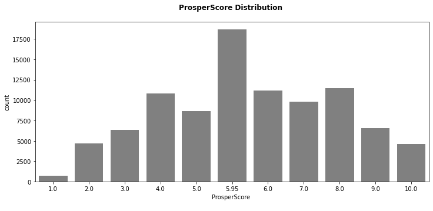

```python
plt.figure(figsize=(12, 5))
sb.countplot(data=loan_df, x='ProsperScore', color='grey', order=ProsperScore_Order)
plt.xlabel('ProsperScore \n')
plt.title('ProsperScore Distribution \n', fontweight='bold');
```

*The distribution shows ProsperScore Values of **5.95** was most associated to borrowers with scores of **4**,**6**, **7** and **8** also dominant as well. It also appears to have a symmetrical distribution*

## *Comparing the Loan Status of Borrowers*

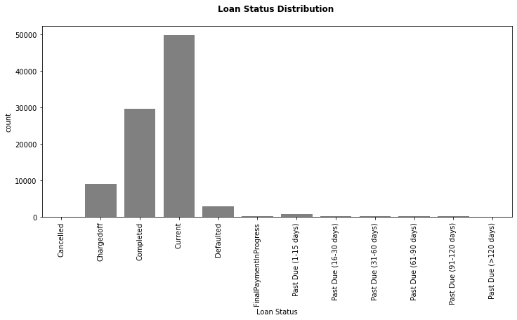

```python
plt.figure(figsize=(12, 5))
sb.countplot(data=loan_df, x='LoanStatus', color='grey')
plt.xlabel('Loan Status')
plt.xticks(rotation = 90)
plt.title('Loan Status Distribution \n', fontweight='bold');
```

*Again the lower values seem almost invisible hence we want to use the the log scale*

## *Log scale distribution of Borrowers LoanStatus*

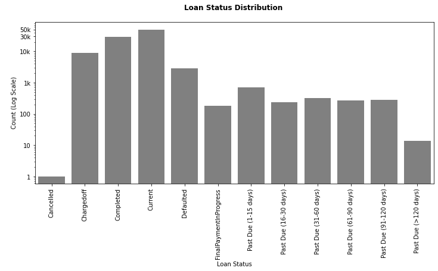

```python
plt.figure(figsize=(12, 5))
sb.countplot(data=loan_df, x='LoanStatus', color='grey')
plt.xlabel('Loan Status')
plt.ylabel('\n Count (Log Scale)')
plt.yscale('log')
plt.xticks(rotation = 90)
plt.yticks([1,10, 100, 1e3, 1e4, 3e4, 5e4], [1, 10, 100, '1k', '10k', '30k', '50k' ])
plt.title('Loan Status Distribution \n', fontweight='bold');
```

*Majority of borrowers still seem to own with a large chunk as well having completed and charge off. A small perentage however seem to more than 120 days due and also cancelled their loans*

## *How is the distribution of BorrowerAPR*

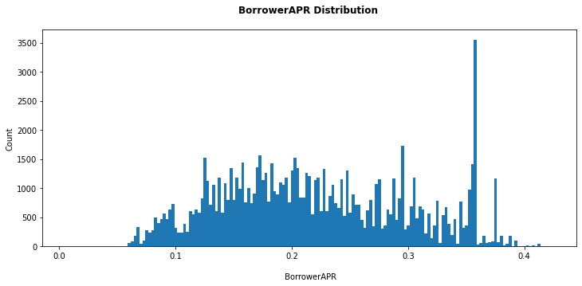

```python
bins = np.arange(loan_df.BorrowerAPR.min(), loan_df.BorrowerAPR.max()+0.0025, 0.0025)
plt.figure(figsize=(12, 5))
plt.hist(data = loan_df, x='BorrowerAPR', bins = bins)
plt.xlabel('\n BorrowerAPR')
plt.ylabel('Count')
# plt.ylim(0, 1750)
plt.title('BorrowerAPR Distribution \n', fontweight='bold');
```

*The **BorrowerAPR** seems to have a fairly symmetrical shapeby counts with values ranging from around **0.05** to **0.4**. A high number of borrowers seems to have an APR of around 0.35*

## *How is the Prosper Rating (Alpha) Distributed*

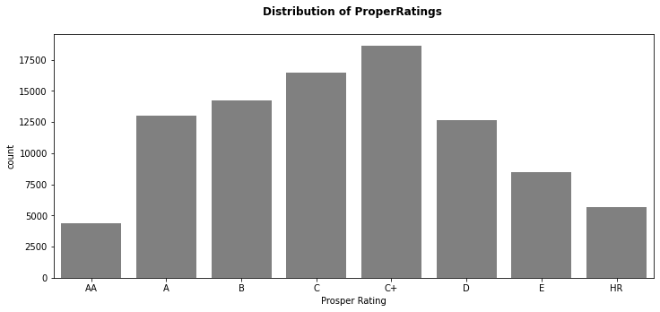

```python
plt.figure(figsize =(12, 5))
sb.countplot(data= loan_df, x='ProsperRating (Alpha)', color = 'grey')
plt.xlabel('Prosper Rating')
plt.title('Distribution of ProperRatings \n', fontweight='bold');
```

*It appears more members were rated at **C** and slightly above **C**. Those with the least counts appear to be those with the best Ratings which is to be expected under most circumstances.*

## Bivariate Exploration

> In this section, we will investigate relationships between pairs of variables in our data.

## *How does loan amounts compare to the monthly income of Borrowers*

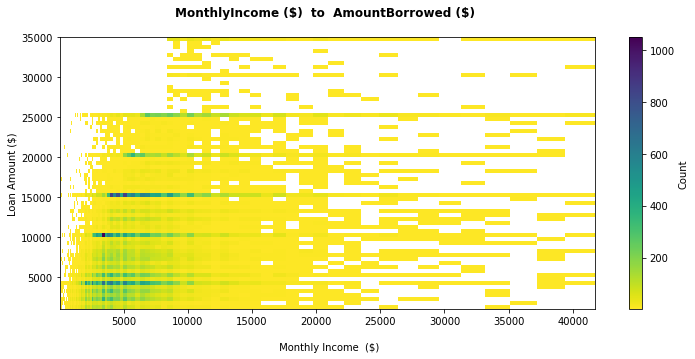

```python
# 0.0833 was a result of the least montly income greater than 0
bins_x = 10 ** np.arange(np.log10(loan_df['StatedMonthlyIncome'].min()+0.083333), np.log10(40000) + 0.025, 0.025) #monthly income less than 0 was excluded as log of 0 is not defined
bins_y = np.arange(loan_df.LoanOriginalAmount.min(), loan_df.LoanOriginalAmount.max()+500, 500)

# Use cmin to set a minimum bound of counts
# Use cmap to reverse the color map.
plt.figure(figsize = (12,5))
h2d = plt.hist2d(data = loan_df, x = 'StatedMonthlyIncome', y = 'LoanOriginalAmount', cmin=0.5, cmap='viridis_r', bins = [bins_x, bins_y])
plt.colorbar(label='Count')
plt.xlabel('\n Monthly Income  (\$)')
plt.ylabel('Loan Amount (\$)')
plt.title("MonthlyIncome (\$)  to  AmountBorrowed (\$) \n", fontweight ='bold');
```

## *How does Occupation compare to monthly income*

*Lets have a barplot for this to see what may be going on hear*

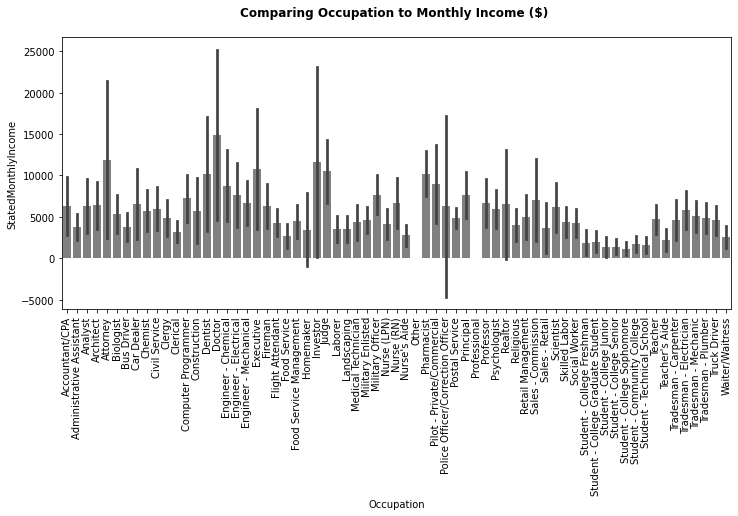

```python
plt.figure(figsize=(12, 5))
sb.barplot(data=exclude_other_professional, x='Occupation', y='StatedMonthlyIncome', color='grey', ci='sd')
plt.xticks(rotation =90);
plt.title('Comparing Occupation to Monthly Income (\$) \n', fontweight='bold');
```

*There appears to be varying spreads across the Occupation but lets try using a line plot instead for clarity. Lets try point plots instead for a clearer view of the spread for these values*

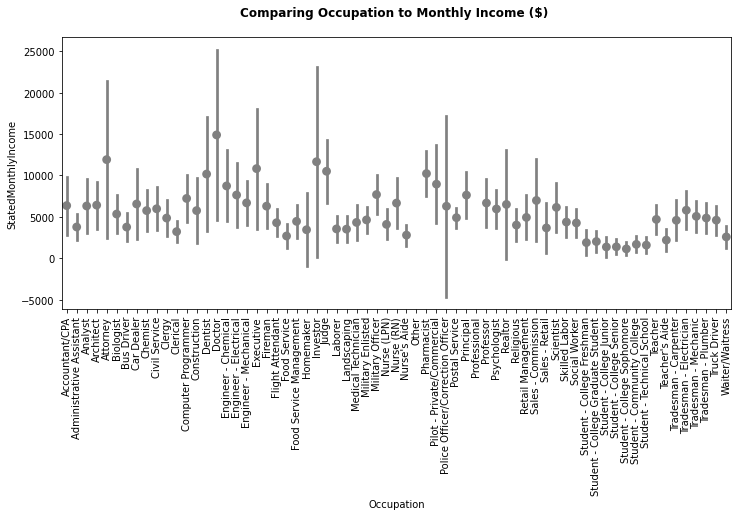

```python
plt.figure(figsize = [12, 5])

# using the dataset without Other and Professional Occupations
sb.pointplot(data=exclude_other_professional, x='Occupation', y='StatedMonthlyIncome', ci='sd', linestyles="",
             color = 'grey')
plt.title('Comparing Occupation to Monthly Income (\$) \n', fontweight='bold')
plt.xticks(rotation = 90);
```

*In as much as **Computer Programing**, **Executive** and **Teaching** dominated the counts, it appears **Teaching** occupation salaries are more concentrated within the **\$65k** salary range. While **Computer Programing** and **Executive** may seem to have higher Monthly Incomes, it appears they are much spread out especially the latter. It also appears the range in salaries for **doctors**, **Attorneys** and **Investors** vary greatly and being more likely to be found at the lower and higher end of the Monthly Incomes chart*

*Lets compare each occupation to a the stated Monthly Income through with a histogram to see the distribution*

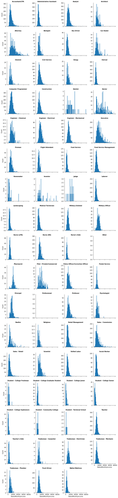

```python
bin_edges = np.arange(loan_df.StatedMonthlyIncome.min(), 40000, 500)

# Plotting within category highest values using the Sharey function in Seaborns Facetgrid function
g = sb.FacetGrid(data = exclude_other_professional, col = 'Occupation', col_wrap=4, sharey=False)
g.map(plt.hist, 'StatedMonthlyIncome', bins = bin_edges)
g.set_ylabels('Count')
g.set_titles('{col_name}', fontweight='bold');
```

*It should be noted the scaling on the y-cordinates are differentn each catergory to have a better assessment for each Occupation due to wide differences in counts. However, the x_cordinates remains the same. The income distributions for most Occupations seems symmetrical in shape with quiet a few of them looking slightly skewed to the right. The various occupations seems to have monthly incomes within the **\$10k** range. **Pilot-Privat/Commercials**, **Investors** as well as **doctors** seem to have varying individual payments as their spread seems quite wide from the data. Doctors and Executives seem to have a fairly large number of people beyound the **\$10k** mark. Being a **doctor** or an **executives** hence, would fairly increase ones chances of obtaining a loan as one is more likely to receive a higher monthly income than other occupations.*

## *How does Listing Category Compare to the Amount of Loan Borrowed*

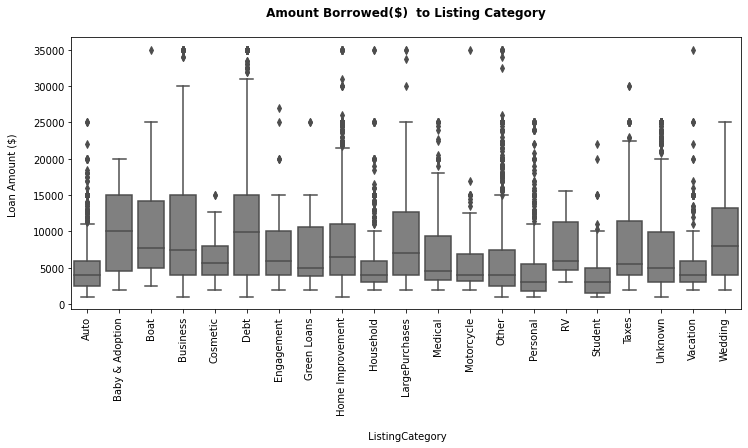

```python
plt.figure(figsize = [12, 5])

# using the dataset without Other and Professional Occupations
sb.boxplot(data=exclude_other_professional, x='ListingCategory', y='LoanOriginalAmount',
           color = 'grey')
plt.xticks(rotation = 90)
plt.xlabel('\n ListingCategory')
plt.ylabel('Loan Amount (\$) \n')
plt.title(' Amount Borrowed($)  to Listing Category \n', fontweight='bold');
```

*Most of these categories seem to gain loans within the **\$15k** range. The various categories seem to have persons associated with sort of high loans. Lets compare each category with the Borrowed amounts to get more insights into the distribrution of these values in its own separate graph using seaborns facetgrid function*

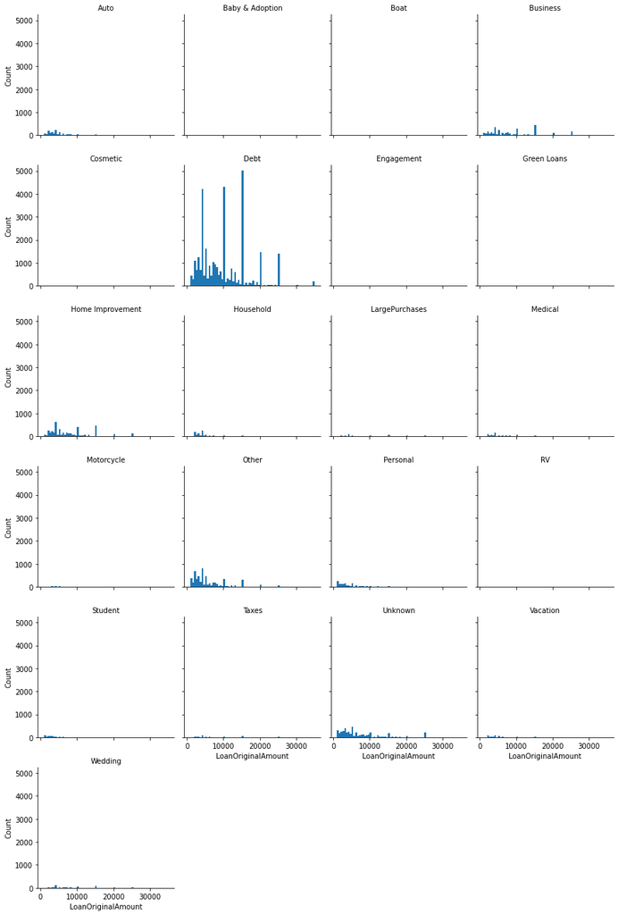

```python
bin_edges = np.arange(loan_df.LoanOriginalAmount.min(), loan_df.LoanOriginalAmount.max()+500, 500)

g = sb.FacetGrid(data = exclude_other_professional, col = 'ListingCategory', col_wrap=4)
g.map(plt.hist, 'LoanOriginalAmount', bins = bin_edges)
g.set_ylabels('Count')
g.set_titles('{col_name}');
```

*It almost seems there are no information for most categories looking at the wide range for the distribution. We would thus, want to plot each categories graph within its highest range of values*

### *Plotting each Category within its highest count range*

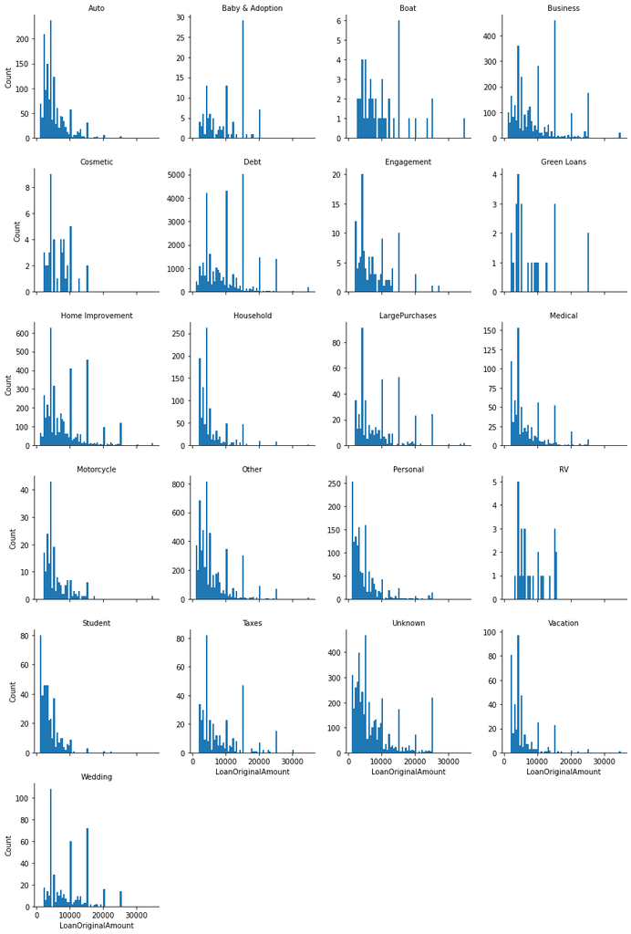

```python
bin_edges = np.arange(loan_df.LoanOriginalAmount.min(), loan_df.LoanOriginalAmount.max()+500, 500)

# Plotting within category highest values using the Sharey function in Seaborns Facetgrid function
g = sb.FacetGrid(data = exclude_other_professional, col = 'ListingCategory', col_wrap=4, sharey=False)
g.map(plt.hist, 'LoanOriginalAmount', bins = bin_edges)
g.set_ylabels('Count')
g.set_titles('{col_name}');
```

*It should be notted that, the **scaling for the y-axis varies for each category**. Most of the graphs looks positively skewed. Like the previous graphs, most of the borrowers received loans mostly within the **\$15k** range limit. It appears a large number of borrowers from the categories of **debt** were given loan. Some debt persons even received money within the **\$20k** to **\$30k** loan values as they recorded some hikes within those regions as well. Almost all students did not exceed loans above **\$10k**. The **others** and **Unknown** categories also recorded some significant counts as well for their members who did receive the loans.*

### *Broader view of Loan Distribution of persons in the Debt Category*

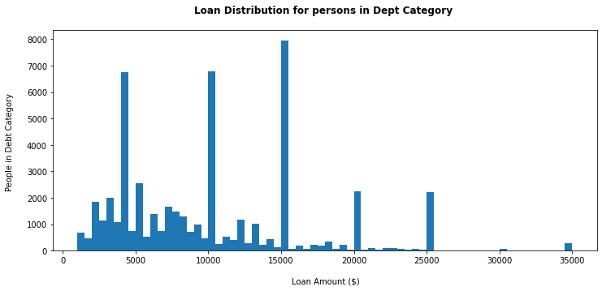

```python
bins = np.arange(loan_df.LoanOriginalAmount.min(), loan_df.LoanOriginalAmount.max()+100, 500)
plt.figure(figsize=(12,5))
plt.hist(data=loan_df.loc[loan_df.ListingCategory == 'Debt'], x='LoanOriginalAmount', bins=bins)
plt.xlabel('\n Loan Amount ($)')
plt.ylabel('People in Debt Category \n')
plt.title('Loan Distribution for persons in Dept Category \n', fontweight='bold');
```

*Just like the graph above, it appears a large number of persons in the dept Category received loan amounts of around **\$15k** with large amounts recorded at both **\$10k** and **\$4k** as well. Beyound **\$15k** however, where majority of borrowers reside, high number of persons are seen at the **\$20k** and **\$25k** loan marks as well.*

### *Distribution of Loan Amounts of Borrowers who are Doctors and in the Debt Category*

```python
# Borrowers in Debt Category and is a Doctor
Debt_Doctor= (loan_df.loc[(loan_df.ListingCategory == 'Debt') & (loan_df.Occupation == 'Doctor')])
```

```python
# comparing total doctors to doctors in Debt Category
len(loan_df.loc[loan_df.Occupation == 'Doctor'].index), len(Debt_Doctor.index)
```

```
(394, 187)
```

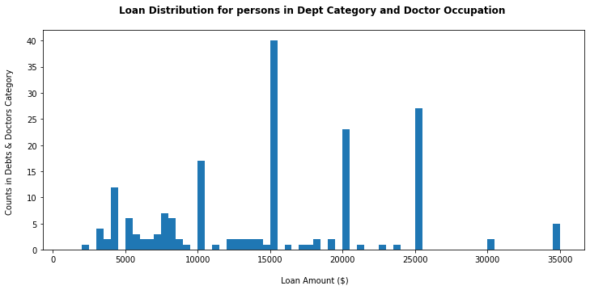

```python
bins = np.arange(loan_df.LoanOriginalAmount.min(), loan_df.LoanOriginalAmount.max()+100, 500)
plt.figure(figsize=(12,5))
plt.hist(data=Debt_Doctor, x='LoanOriginalAmount', bins=bins)
plt.xlabel('\n Loan Amount ($)')
plt.ylabel('Counts in Debts & Doctors Category \n')
plt.title('Loan Distribution for persons in Dept Category and Doctor Occupation \n', fontweight='bold');
```

*Of the **187 doctors** in the debt categories it appears more than **50%** of them received loans above **\$10k**. It appears doctors in this category much higher loans than the average loan amount.*

## *How does Occupation Compare to ProsperScore*

```python
# checking occupation column values
loan_df.Occupation.value_counts()
```

```
Other                          23059
Professional                   11906
Computer Programmer             3799
Executive                       3687
Teacher                         3392
                               ...
Student - College Sophomore       38
Student - College Freshman        28
Judge                             21
Student - Community College       14
Student - Technical School         7
Name: Occupation, Length: 67, dtype: int64
```

*The occupations considered as **Professional** and **Other** seem confusing as Jobs such as Teaching, Judging and many others could be considered Professional as well. Also, the other occupation category sounds confusing as labor, capentary and many others could all be classified as others as well. We would hence drop these columns for easy understanding*

```python
# droping professional and Other Occupation from occupation column
exclude_other_professional = loan_df[~((loan_df.Occupation == 'Other') | (loan_df.Occupation == 'Professional'))] # ~ means exclude

# Grouping each Occupation and counting the prosperScore associated with each
occup_and_pros_counts = exclude_other_professional.groupby(['Occupation', 'ProsperScore']).size()
occup_and_pros_counts
```

```
Occupation       ProsperScore
Accountant/CPA   1.0              27
                 2.0             141
                 3.0             193
                 4.0             266
                 5.0             257
                                ...
Waiter/Waitress  6.0              36
                 7.0              24
                 8.0              30
                 9.0              18
                 10.0              8
Length: 737, dtype: int64
```

```python
# Using Series.reset_index() to convert a series into a dataframe object
occup_and_pros_counts = occup_and_pros_counts.reset_index(name='count')
occup_and_pros_counts
```

|  | Occupation | ProsperScore | count |
| --- | --- | --- | --- |
| 0 | Accountant/CPA | 1.0 | 27 |
| 1 | Accountant/CPA | 2.0 | 141 |
| 2 | Accountant/CPA | 3.0 | 193 |
| 3 | Accountant/CPA | 4.0 | 266 |
| 4 | Accountant/CPA | 5.0 | 257 |
| ... | ... | ... | ... |
| 732 | Waiter/Waitress | 6.0 | 36 |
| 733 | Waiter/Waitress | 7.0 | 24 |
| 734 | Waiter/Waitress | 8.0 | 30 |
| 735 | Waiter/Waitress | 9.0 | 18 |
| 736 | Waiter/Waitress | 10.0 | 8 |

737 rows × 3 columns

```python
# Using DataFrame.pivot() to rearrange the data, to have Occupation on rows
occup_and_pros_counts = occup_and_pros_counts.pivot(index = 'ProsperScore', columns = 'Occupation', values = 'count')
occup_and_pros_counts
```

| Occupation ProsperScore | Accountant/CPA | Administrative Assistant | Analyst | Architect | Attorney | Biologist | Bus Driver | Car Dealer | Chemist | Civil Service | Clergy | Clerical | Computer Programmer | Construction | Dentist | Doctor | Engineer - Chemical | Engineer - Electrical | Engineer - Mechanical | Executive | Fireman | Flight Attendant | Food Service | Food Service Management | Homemaker | Investor | Judge | Laborer | Landscaping | … |
| --- | --- | --- | --- | --- | --- | --- | --- | --- | --- | --- | --- | --- | --- | --- | --- | --- | --- | --- | --- | --- | --- | --- | --- | --- | --- | --- | --- | --- | --- | --- |
| 1.0 | 27 | 41 | 20 | 0 | 4 | 0 | 2 | 0 | 3 | 16 | 0 | 26 | 25 | 4 | 0 | 3 | 3 | 3 | 5 | 25 | 6 | 0 | 6 | 5 | 0 | 0 | 0 | 9 | 1 | … |
| 2.0 | 141 | 189 | 130 | 5 | 27 | 9 | 27 | 9 | 6 | 63 | 9 | 183 | 114 | 64 | 3 | 13 | 8 | 38 | 45 | 122 | 22 | 6 | 72 | 65 | 5 | 3 | 0 | 107 | 4 | … |
| 3.0 | 193 | 256 | 176 | 5 | 42 | 4 | 17 | 9 | 7 | 95 | 10 | 263 | 159 | 76 | 6 | 11 | 7 | 51 | 80 | 201 | 20 | 14 | 100 | 87 | 1 | 2 | 0 | 135 | 6 | … |
| 4.0 | 266 | 427 | 329 | 13 | 68 | 15 | 51 | 20 | 12 | 160 | 26 | 356 | 257 | 182 | 5 | 24 | 13 | 109 | 130 | 352 | 30 | 15 | 138 | 143 | 5 | 6 | 5 | 201 | 13 | … |
| 5.0 | 257 | 360 | 283 | 14 | 50 | 7 | 19 | 13 | 10 | 142 | 19 | 263 | 260 | 113 | 7 | 28 | 10 | 66 | 118 | 294 | 47 | 13 | 86 | 113 | 2 | 5 | 1 | 155 | 14 | … |
| 5.95 | 487 | 726 | 656 | 47 | 122 | 24 | 53 | 18 | 29 | 253 | 27 | 660 | 871 | 311 | 9 | 78 | 38 | 166 | 201 | 607 | 81 | 27 | 218 | 180 | 18 | 2 | 0 | 267 | 35 | … |
| 6.0 | 363 | 426 | 329 | 11 | 101 | 13 | 41 | 20 | 18 | 166 | 28 | 321 | 362 | 149 | 9 | 38 | 21 | 100 | 145 | 392 | 40 | 12 | 103 | 150 | 1 | 4 | 1 | 186 | 15 | … |
| 7.0 | 289 | 320 | 314 | 22 | 67 | 13 | 28 | 19 | 11 | 155 | 14 | 267 | 374 | 151 | 3 | 31 | 29 | 116 | 148 | 420 | 44 | 8 | 74 | 103 | 2 | 9 | 0 | 155 | 15 | … |
| 8.0 | 397 | 334 | 481 | 24 | 139 | 10 | 32 | 13 | 14 | 174 | 8 | 217 | 567 | 145 | 3 | 79 | 36 | 147 | 187 | 556 | 52 | 7 | 73 | 143 | 2 | 11 | 7 | 126 | 9 | … |
| 9.0 | 255 | 154 | 293 | 23 | 95 | 12 | 16 | 11 | 9 | 78 | 12 | 109 | 429 | 100 | 4 | 47 | 22 | 111 | 123 | 380 | 27 | 9 | 38 | 75 | 3 | 12 | 3 | 62 | 2 | … |
| 10.0 | 174 | 76 | 256 | 12 | 88 | 8 | 6 | 6 | 16 | 59 | 14 | 46 | 381 | 57 | 3 | 42 | 20 | 101 | 95 | 338 | 22 | 2 | 24 | 42 | 0 | 9 | 4 | 20 | 2 | … |

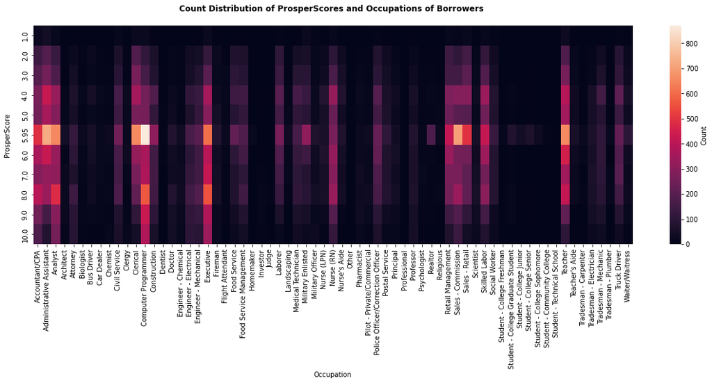

```python
plt.figure(figsize=(20,6))
sb.heatmap(occup_and_pros_counts, annot = False, fmt = 'd', cbar_kws = {'label' : 'Count'})
plt.ylabel('ProsperScore \n')
plt.title('Count Distribution of ProsperScores and Occupations of Borrowers \n', fontweight='bold');
```

*The graph clearly depicts the prosperscores at the lowest and highest ends recorded the least counts. Most occupations received ratings between **4.0** and **8.0**. A large number of computer programmers seemed to have given a score of **5.95**. Most of the Occupations seemed to have received a large number of rating for **5.95** as well. It should as well be noted the professional and other Occupations are excluded from the dataframe used.*

## *How does ProsperScore compare to BorrowerAPR*

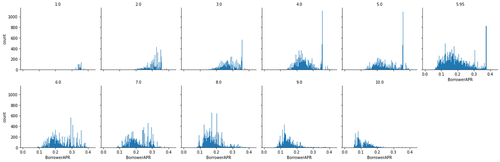

```python
g = sb.FacetGrid(data = loan_df, col = 'ProsperScore', col_wrap = 6, height = 3,col_order = ProsperScore_Order)

g.map(plt.hist, 'BorrowerAPR', bins = np.arange(loan_df.BorrowerAPR.min(), loan_df.BorrowerAPR.max()+0.0025, 0.0025))
g.set_ylabels('count')
g.set_titles('{col_name}');
```

*It appears borrowers with the lowest ProsperScore seemed to have had a high APR value compared to the highest ProsperScore value.The **APR values seemed to have been reducing gradually** with increase in the ProsperScore values. A large percentage of borrowers seemed to have ProsperScore values of **5.95** with APR values from somewhere around **0.05** to **0.35**.*

## *How does BorrowerAPR values compare to the Amounts Borrowed*

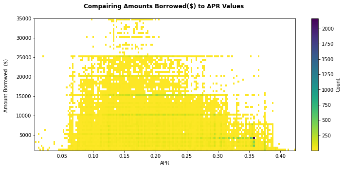

```python
# Specify bin edges
bins_x = np.arange(loan_df.BorrowerAPR.min(), loan_df.BorrowerAPR.max()+0.0025, 0.0025)
bins_y = np.arange(loan_df.LoanOriginalAmount.min(), loan_df.LoanOriginalAmount.max()+500, 500)

plt.figure(figsize=(12,5))
plt.hist2d(data = loan_df, x = 'BorrowerAPR', y = 'LoanOriginalAmount', cmin=0.5, cmap='viridis_r', bins=[bins_x, bins_y])
plt.colorbar(label='Count')
plt.xlabel('APR')
plt.ylabel('Amount Borrowed  (\$) \n')
plt.title('Compairing Amounts Borrowed($) to APR Values \n', fontweight='bold');
```

*In general, there were not a large number of people with high APR values from this graph. Majority of the amounts borrowed seems to have had an APR value between **0.05** and **0.4**. A large number of borrowers seemed to have had borrowed amounts somewhere around **\$4k** and an APR value slighly over **0.35**. There is also a fairly large number of persons who borrowed **\$15k** and **\$10k** with an APR value ranging from around **0.13** to **0.25**. In general, the largest APR values seemed to have been associated with persons who borrowed the least amounts*

## *How does BorrowerAPR values compare to the Montly Earnings of the Borrowers*

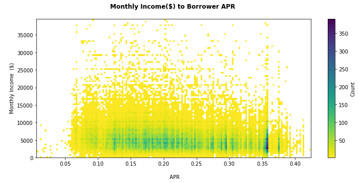

```python
# Specify bin edges
bins_x = np.arange(loan_df.BorrowerAPR.min(), loan_df.BorrowerAPR.max()+0.0025, 0.0025)
bins_y = np.arange(loan_df.StatedMonthlyIncome.min(), 40000, 500) # monthly Income limited to 40,000

plt.figure(figsize=(12,5))
plt.hist2d(data = loan_df, x = 'BorrowerAPR', y = 'StatedMonthlyIncome', cmin=0.5, cmap='viridis_r', bins=[bins_x, bins_y])
plt.colorbar(label= 'Count')
plt.xlabel('\n APR')
plt.ylabel('\n Monthly Income  (\$)')
plt.title('Monthly Income(\$) to Borrower APR \n', fontweight ='bold');
```

*Again, a large number of persons with monthly income somewhere between **\$1k** and **\$10k** seem to have their APR values between **0.13%** and **0.36%**. The borrowed amounts seemed to drop gradually as the **APR** values increase*

### Did you observe any interesting relationships between the other features (not the main feature(s) of interest)?

> - *For the same occupation, there appears to large differences in the monthly income.*
> - *Almost half of the doctors come for loan under categories of dept which is strange as their salary distribution shows they usally obtain more than **\$10k** which is where a chuck of the borrowers reside in as well.*
> - *Many people being granted loan under the pretext of debt seems a bit strange, since someone who owns is more likely to own again*

## *Compare the correlation between monthly Income, Borrowed Amount, Monthly loan payment, Estimated Effective Yield, Interest rate and APR*

```python
loan_df.head(2)
```

|  | CreditGrade | Term | LoanStatus | BorrowerAPR | BorrowerRate | LenderYield | EstimatedEffectiveYield | EstimatedLoss | EstimatedReturn | ProsperRating | ProsperRating (Alpha) | ProsperScore | ListingCategory | BorrowerState | Occupation | EmploymentStatus | EmploymentStatusDuration | IsBorrowerHomeowner | CurrentlyInGroup | CreditScoreRangeLower | CreditScoreRangeUpper | FirstRecordedCreditLine | CurrentCreditLines | OpenCreditLines | TotalCreditLinespast7years | OpenRevolvingAccounts | OpenRevolvingMonthlyPayment | InquiriesLast6Months | TotalInquiries | … |
| --- | --- | --- | --- | --- | --- | --- | --- | --- | --- | --- | --- | --- | --- | --- | --- | --- | --- | --- | --- | --- | --- | --- | --- | --- | --- | --- | --- | --- | --- | --- |
| 0 | C | 36 | Completed | 0.16516 | 0.158 | 0.138 | 0.13064 | 0.080306 | 0.088356 | 4.072243 | C+ | 5.95 | Unknown | CO | Other | Self-employed | 2.0 | True | True | 640.0 | 659.0 | 2001-10-11 00:00:00 | 5.0 | 4.0 | 12.0 | 1 | 24.0 | 3.0 | 3.0 | … |
| 1 | NONE | 36 | Current | 0.12016 | 0.092 | 0.082 | 0.07960 | 0.024900 | 0.054700 | 6.000000 | A | 7.00 | Home Improvement | CO | Professional | Employed | 44.0 | False | False | 680.0 | 699.0 | 1996-03-18 00:00:00 | 14.0 | 14.0 | 29.0 | 13 | 389.0 | 3.0 | 5.0 | … |

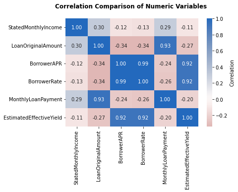

```python
# determining the correlation among some numeric variabels
sb.heatmap(loan_df[['StatedMonthlyIncome', 'LoanOriginalAmount', 'BorrowerAPR', 'BorrowerRate', 'MonthlyLoanPayment', 'EstimatedEffectiveYield']].corr(),
           annot = True, fmt = '.2f', cmap = 'vlag_r', center = 0, cbar_kws = {'label' : 'Correlation'})
plt.title('Correlation Comparison of Numeric Variables \n', fontweight='bold' );
```

*There seems to be a high correlation between the BorrowerAPR and the BorrowerRate as well as the Estimated Effective Yield and the APR values. This is understanding as higher APR values may imply the borrower have to pay a higher interest which is more likely to generate much funds to the lenders othe loan hence much possible to gain from this. Also, depending on the loan on is granted, the monthly loan payment could be desided. Th correlation the two columns looks positive hence a higher loan would attract a higher mont=hly payment which is placible. The yield and montly incom seem to have a week corelation.*

## *Comparing Prosper Ratings to APR and Loan Amouns*

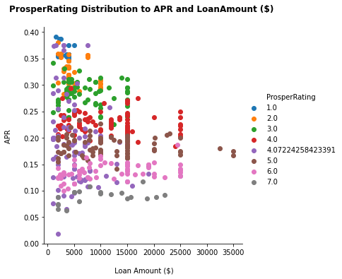

```python
plt.figure(figsize=(12, 5))
g = sb.FacetGrid(data = loan_df.sample(500), hue = 'ProsperRating', height = 5)
g.map(plt.scatter, 'LoanOriginalAmount', 'BorrowerAPR', cmap='red');
g.set(xlabel ='\n Loan Amount (\$)', ylabel='APR \n')
g.add_legend();
plt.title('ProsperRating Distribution to APR and LoanAmount (\$) \n', fontweight='bold');
```

*Lower prosper ratings are associated with higher APR values and lower amounts borrowed. Loan amounts beyound **\$15k** seem to have prosper ratings above **3.0**.*

## *How does the Amount Borrowed, Monthly income and APR Compare*

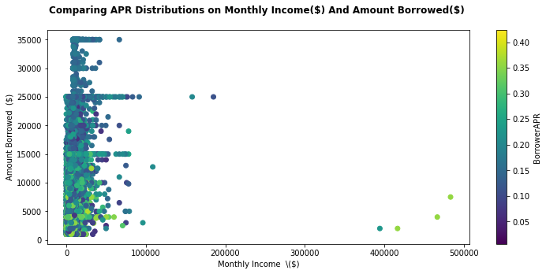

```python
plt.figure(figsize = [12,5])
plt.scatter(data = loan_df, x = 'StatedMonthlyIncome', y = 'LoanOriginalAmount',
                c = 'BorrowerAPR')
plt.colorbar(label = 'BorrowerAPR')
plt.xlabel('Monthly Income  \($)')
plt.ylabel('Amount Borrowed  (\$)')
plt.title('Comparing APR Distributions on Monthly Income(\$) And Amount Borrowed(\$) \n', fontweight ='bold');
```

> - *The plots looks clustered within the **\$50k** monthly income range. Lets try and limit the monthly income to about a **\$100k** or better still **\40k** as a large number of the population receive monthly income within this range.*
> - *Also, lets try and use a sample size of about **1,000** to reduce overploting within the graph to be generated.*

```python
loan_df.shape[0]
```

```
93462
```

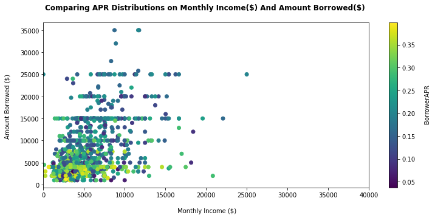

```python
plt.figure(figsize = [12,5])
plt.scatter(data = loan_df.sample(1000), x = 'StatedMonthlyIncome', y = 'LoanOriginalAmount',
                c = 'BorrowerAPR')
plt.colorbar(label = '\n BorrowerAPR')
plt.xlim(0,40000) #o Most of the Monthly Income lies within this range
plt.xlabel('\n Monthly Income (\$)')
plt.ylabel('Amount Borrowed (\$) \n')
plt.title('Comparing APR Distributions on Monthly Income(\$) And Amount Borrowed(\$) \n', fontweight='bold');
```

*In almost all instances, persons with lower monthly income and lower amounts borrowed seemed to have a high borrower APR. Most of these persons seemed to have been within the monthly income of about **\$15k** and borrowed amount of up to **\$15k** as well.*

*These trend is even more visible when we try using a much smaller sample size*

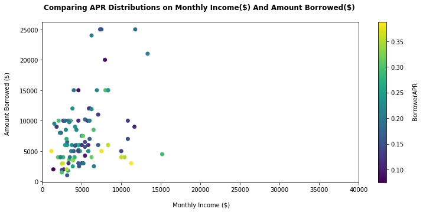

```python
plt.figure(figsize = [12,5])
plt.scatter(data = loan_df.sample(100), x = 'StatedMonthlyIncome', y = 'LoanOriginalAmount',
                c = 'BorrowerAPR')
plt.colorbar(label = '\n BorrowerAPR')
plt.xlim(0,40000)
plt.xlabel('\n Monthly Income (\$)')
plt.ylabel('Amount Borrowed (\$) \n')
plt.title('Comparing APR Distributions on Monthly Income(\$) And Amount Borrowed(\$) \n', fontweight='bold');
```

*It appears the higher borrower APR's are even much dominant within the **\$10k** regions of both montly income and amounts borrowed hence borrowing or having monthly incomes above this regions is much likely to save one from high APR values from prosper's platform.*

## *Comparing Loan Amount and Monthly Income on a logarithmic scale*

> - *Lets first scaling the Monthly income on a log scale*

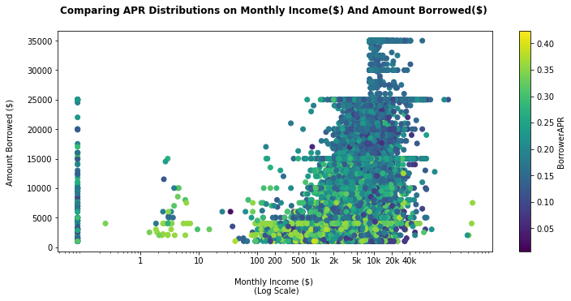

```python
plt.figure(figsize = [12,5])
plt.scatter(data = loan_df, x = 'StatedMonthlyIncome', y = 'LoanOriginalAmount',
                c = 'BorrowerAPR')
plt.colorbar(label = 'BorrowerAPR')
plt.ylabel('Amount Borrowed ($) \n')
plt.xscale('log')
plt.xticks([1, 10, 100, 200, 500, 1e3, 2e3, 5e3,  1e4, 2e4, 4e4], [1, 10, 100, 200, 500, '1k', '2k', '5k', '10k', '20k', '40k'])
plt.xlabel(' \nMonthly Income ($) \n (Log Scale)')
plt.title('Comparing APR Distributions on Monthly Income(\$) And Amount Borrowed(\$) \n', fontweight='bold');
```

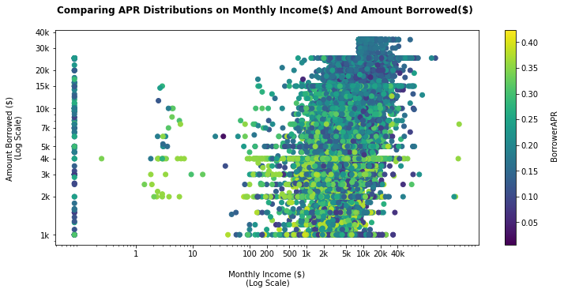

```python
plt.figure(figsize = [12,5])
plt.scatter(data = loan_df, x = 'StatedMonthlyIncome', y = 'LoanOriginalAmount',
                c = 'BorrowerAPR')
plt.colorbar(label = '\n BorrowerAPR')
plt.xscale('log')
plt.yscale('log')
plt.xticks([1, 10, 100, 200, 500, 1e3, 2e3, 5e3,  1e4, 2e4, 4e4], [1, 10, 100, 200, 500, '1k', '2k', '5k', '10k', '20k', '40k'])
plt.xlabel('\n Monthly Income ($) \n (Log Scale)')
plt.ylabel('Amount Borrowed ($) \n (Log Scale) \n')
plt.yticks([1e3, 2e3, 3e3, 4e3, 5e3, 7e3, 1e4, 1.5e4, 2e4, 3e4, 4e4], ['1k', '2k', '3k', '4k', '5k', '7k', '10k', '15k', '20k', '30k', '40k'])
plt.title('Comparing APR Distributions on Monthly Income(\$) And Amount Borrowed(\$) \n', fontweight='bold');
```

*This seems to stretch out our data points better. At this point we would try and focus more on where our data points reside. Much of the data seem to fall within the **\$30** and **\$40k** monthly income range. We also use about **1,000** samples from our data to prevent overcrowding of data points in our graph*

*Limiting the number of data to prevent overCrowding on graph*

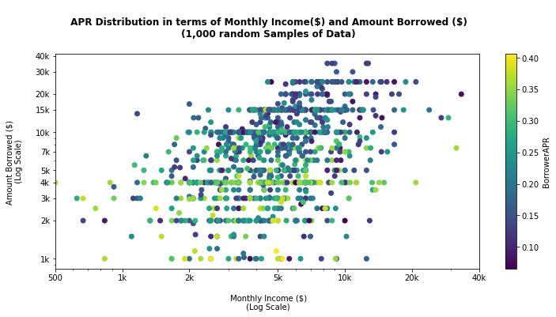

```python
# Using 1,000 random samples to minimize overcrowding of data points
plt.figure(figsize = [12,5])
plt.scatter(data = loan_df.sample(1000), x = 'StatedMonthlyIncome', y = 'LoanOriginalAmount',
                c = 'BorrowerAPR')
plt.colorbar(label = 'BorrowerAPR')
plt.xscale('log')
plt.yscale('log')
plt.xticks([1, 10, 100, 200, 500, 1e3, 2e3, 5e3,  1e4, 2e4, 4e4], [1, 10, 100, 200, 500, '1k', '2k', '5k', '10k', '20k', '40k'])
plt.xlim(500, 40000)
plt.xlabel('\n Monthly Income (\$)\n (Log Scale)')
plt.ylabel('Amount Borrowed ($) \n (Log Scale) \n')
plt.yticks([1e3, 2e3, 3e3, 4e3, 5e3, 7e3, 1e4, 1.5e4, 2e4, 3e4, 4e4], ['1k', '2k', '3k', '4k', '5k', '7k', '10k', '15k', '20k', '30k', '40k'])
plt.title('\n APR Distribution in terms of Monthly Income(\$) and Amount Borrowed (\$)\n (1,000 random Samples of Data)\n', fontweight='bold');
```

*Higher APR values are associated with borrowed amounts somewhere between values slightly below **\$1k** and **\$10k** as well as monthly incomes between a region around **\$1.2k** to **\$10k** on the loagirithmic scale*

## *Compare Loan Amount, BorrowerAPR, Home Ownership Status and the ProsperRating (Alpha)*

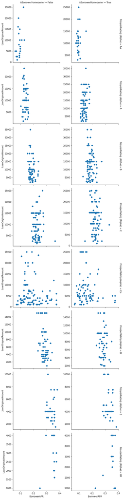

```python
# Lets use the first 1,000 rows of the dataset to prevent over crowding in our plot
g = sb.FacetGrid(data = loan_df[:1000], col = 'IsBorrowerHomeowner', row = 'ProsperRating (Alpha)', height = 4,
                margin_titles = True, sharey = False)
g.map(plt.scatter, 'BorrowerAPR', 'LoanOriginalAmount');
```